# The Lighthouse Problem

Joao Neto

January 2017

# Introduction

Refs:

- D.S.Sivia - [Data Analysis, A Bayesian Tutorial](https://www.amazon.com/dp/0198568320)
- Stephen F. Gull - Bayesian Inductive Inference and Maximum Entropy

This problem was first presented by Stephen F. Gull in 1988 and can be stated as:

> A lighthouse is somewhere off a piece of straight coastline at a position $\alpha$ along the shore and a distance $\beta$ out at sea. It emits a series of short highly collimated flashes at random intervals and hence at random azimuths. These pulses are intercepted on the coast by photo-detectors that record only the fact that a flash has occurred, but not the angle from which it came. N flashes have so far been recorded at positions {$x_k$}. Where is the lighthouse?’ – Sivia, pg.29

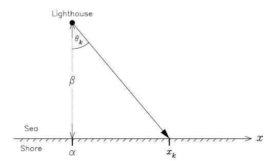

*Problem diagram (also from Sivia)*

As implied in the description, the angle $\theta$ is uniform over $\pm \pi/2$, so

$$p(\theta | \alpha, \beta) = \frac{1}{\pi}$$

The position $x$ is given by

$$x = \beta \tan \theta + \alpha$$

The rule of variable transformation, $p(x) dx = p(\theta) d\theta$, allows us to compute $p(x | \alpha, \beta)$:

$$p(x | \alpha, \beta) = p(\theta | \alpha, \beta) \left| \frac{d\theta}{dx} \right|$$

Since $x = \beta \tan \theta + \alpha$, if we differenciate $\theta$ wrt $x$:

$$\frac{d\theta}{dx} = \beta \sec^2\theta = \beta (\tan^2\theta + 1) =
\beta \left[\left(\frac{x-\alpha}{\beta}\right)^2 + 1\right] = \frac{\beta}{(x-\alpha)^2 + \beta^2}$$

So, getting back to $p(x | \alpha, \beta)$:

$$p(x | \alpha, \beta) = p(\theta | \alpha, \beta) \left| \frac{d\theta}{dx} \right| = \frac{1}{\pi} \frac{\beta}{(x-\alpha)^2 + \beta^2}$$

This distribution is precisely the [Cauchy distribution](http://mathworld.wolfram.com/CauchyDistribution.html). It has two parameters, $x_0$, location (which we called $\alpha$, above), and $\beta>0$, scale:

$$p(x|x_0,\beta) = \frac{1}{\pi} \frac{\beta}{(x-x_0)^2 + \beta^2}$$

Notice that this is a two paramater problem, $\alpha$ and $\beta$.

# Known $\beta$

First, let’s consider we know $\beta$, the distance from shore, and we wish to find

$$p(\alpha | \{x_k\}, \beta)$$

Using Bayes’ theorem:

$$p(\alpha | \{x_k\}, \beta) \propto p(\{x_k\} | \alpha, \beta) p(\alpha | \beta)$$

and since $\alpha \perp \beta$, $p(\alpha | \beta) = p(\alpha)$.

The prior $p(\alpha)$ can be modelled by a uniform over a large enough segment $[x_{min}, x_{max}]$, ie, $p(\alpha) = 1/(x_{max}-x_{min})$.

For the data likelihood $p(\{x_k\} | \alpha, \beta)$ we consider that each datum $x_k$ is iid, so:

$$p(\{x_k\} | \alpha, \beta) = \prod_{k=1}^N p(x_k | \alpha, \beta)$$

And since the prior for $\alpha$ is uniform, we finally get:

$$p(\alpha | \{x_k\}, \beta) \propto p(\{x_k\} | \alpha, \beta)$$

Let’s try some R.

The next function is a factory that creates the log posterior function for a given data:

```r
# outputs function log p(alpha|x_k,beta)
#
# computes the cauchy pdf for the likelihood p(x_k|alpha,beta), since the prior(alpha)
# is constant and does not contribute to find the posterior distribution shape
make_log_posterior <- function (x_k, beta) {
  Vectorize(function (alpha_hat) {
              sum( log((beta/pi) / (beta^2 + (x_k - alpha_hat)^2)) )
           })
}
```

Let’s create a dataset:

```r
alpha <- 10 # unkonwn true values
beta  <- 30 # this is known for now
##################
set.seed(123)
N       <- 1024
theta_k <- runif(N,-pi/2,pi/2)
x_k     <- beta * tan(theta_k) + alpha
```

And check it:

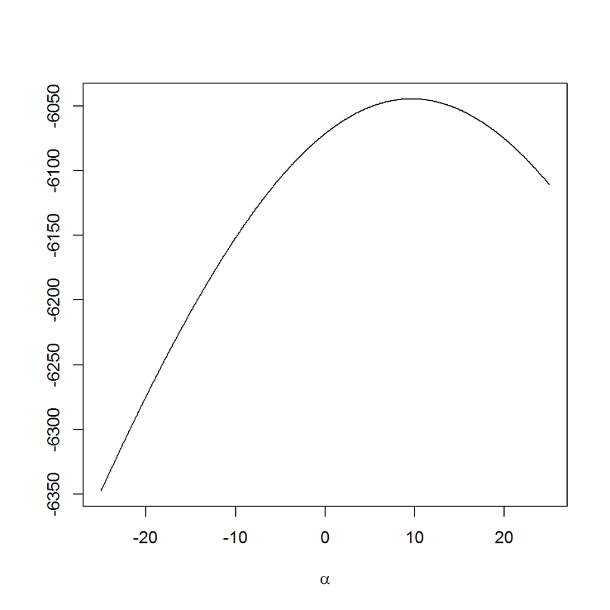

```r
log_posterior <- make_log_posterior(x_k, beta)
curve(log_posterior, from=-25, to=25, n=500, xlab=bquote(alpha), ylab="")
```

We see that there’s a maximum over there, but we are working with logs (btw, we must work with logs to make sums, since working directly with products would easily result in under/overflows).

After the logs are computed, we can get the shape of the posterior (to get the true posterior – a distribution – we would need to find the normalizing factor, which is irrelevant here):

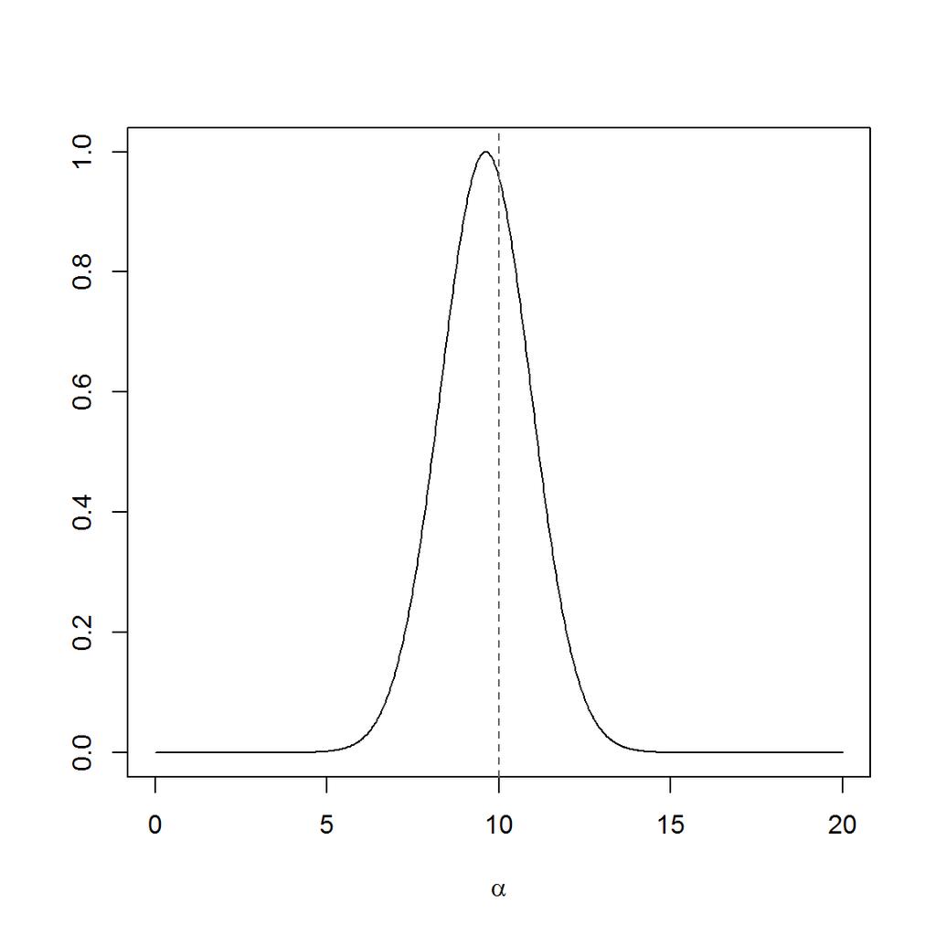

```r
posterior_shape <- function(xs, log_posterior) {
  log_alphas    <- log_posterior(xs)        # compute log posterior for a grid of values
  log_alpha_max <- max(log_alphas)
  alphas <- exp(log_alphas - log_alpha_max) # subtract from L_max, and exponentiate
  alphas                                    #  then the max value will be 1
}

xs <- seq(0,20,len=1000)
plot(xs, posterior_shape(xs, log_posterior), type="l", xlab=bquote(alpha), ylab="")
abline(v=alpha, col="grey40", lty=2)
```

The likelihood is given by a Cauchy, which is a symmetric distribution, and it would be natural to assume that the mean would be a good estimator. However:

```r
mean(x_k)
```

```
## [1] -17.72149
```

The mean is not a good estimator because we cannot apply the [Central Limit Theorem](https://en.wikipedia.org/wiki/Central_limit_theorem) (CLT). The CLT only works when the data is iid (which it is) and sampled from a distribution with finite mean (which it is not). *The Cauchy does not have a mean*.

The Cauchy does have a median, $x_0$, which can be used as an estimator here:

```r
median(x_k)
```

```
## [1] 8.964787
```

but does not give as much information as the posterior does.

The posterior might be multimodal when the data is sufficiently appart:

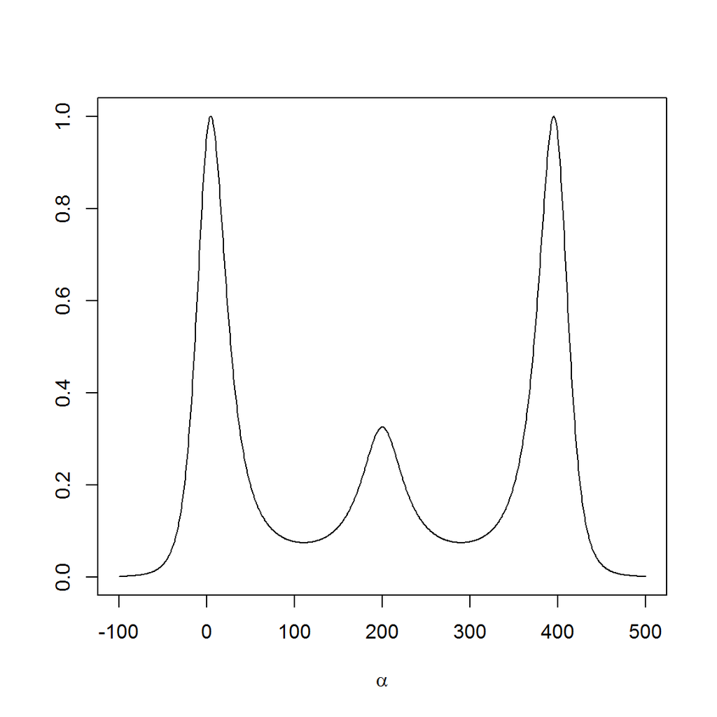

```r
x2_k <- c(0,0,200,400,400)
log_posterior2 <- make_log_posterior(x2_k, beta)

xs <- seq(-100,500,len=1000)
plot(xs, posterior_shape(xs, log_posterior2), type="l", xlab=bquote(alpha), ylab="")
```

# Unknown $\beta$

If we also don’t know $\beta$ then we have to add a prior to it.

Let’s assume $\alpha \perp \beta$, so we get:

$$p(\alpha, \beta | \{x_k\}) \propto p(\{x_k\} | \alpha, \beta) p(\alpha) p(\beta)$$

If we also assume that $\beta$ is uniform over some interval [$0,y_{max}$], then the posterior is proportional to the likelihood:

$$p(\alpha, \beta | \{x_k\}) \propto p(\{x_k\} | \alpha, \beta)$$

We can use R to check how the posterior would look like for our previous eg:

```r
log_joint_posterior <- function (x_k, alfa, beta) {
  sum( log((beta/pi) / (beta^2 + (x_k - alfa)^2)) )
}
```

And check our sample dataset using a grid search:

```r
x_min <- 0; x_max <- 20; y_max <- 50
alphas <- seq(x_min, x_max)
betas  <- seq(    0, y_max)

f <- function(a,b) log_joint_posterior(x_k, a, b)

log_grid_values <- outer(alphas, betas, Vectorize(f))

grid_values <- matrix(posterior_shape(log_grid_values, log_posterior),
                      nrow=length(alphas), ncol=length(betas))
```

This requires a 3D plot:

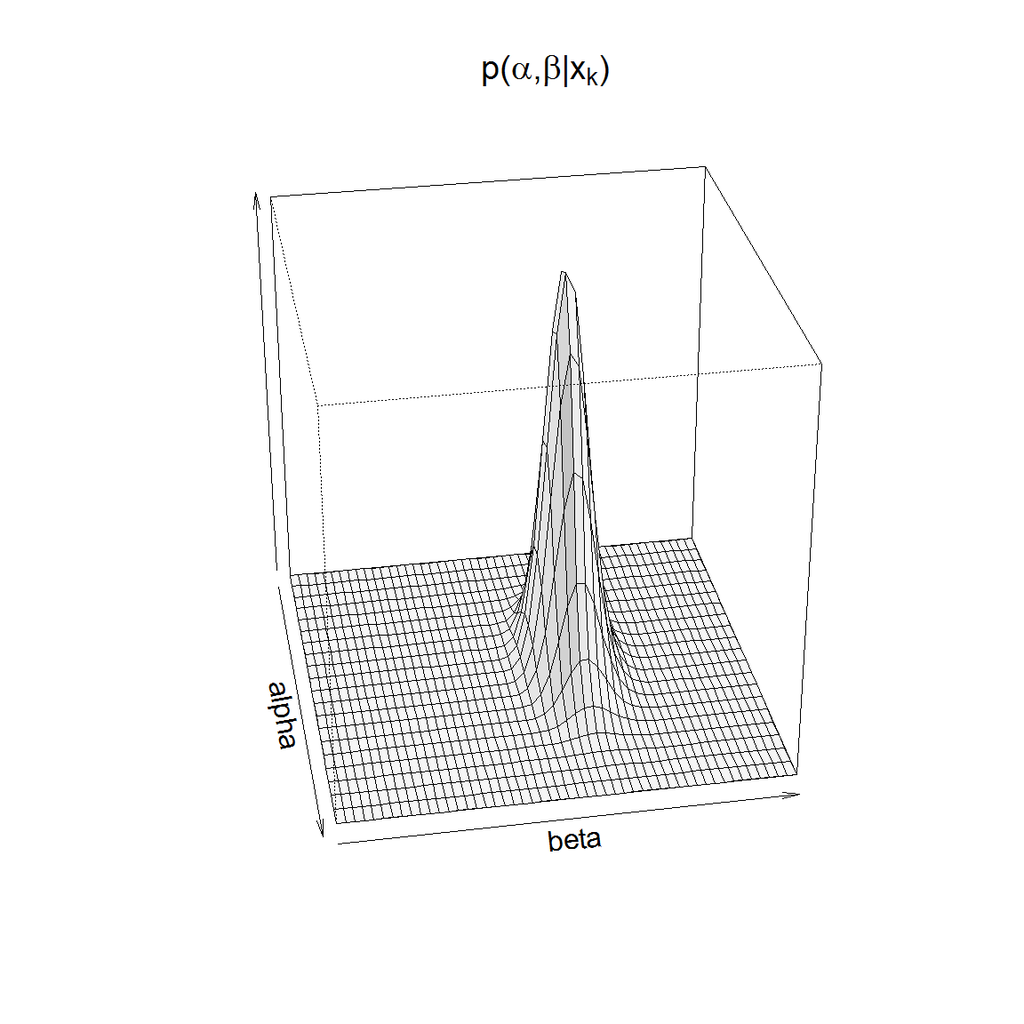

```r
persp(alphas, betas , grid_values,
      xlab=bquote(alpha), ylab=bquote(beta), zlab="",
      main="" , cex=0.7, lwd=0.1  ,
      xlim=c(x_min,x_max), ylim=c(0,y_max), zlim=c(0,1),
      theta=80, phi=30, d=5.0, shade=0.05)
title(bquote(paste(p,"(",alpha,",",beta,"|",x[k],")")))
```

Or a contour map:

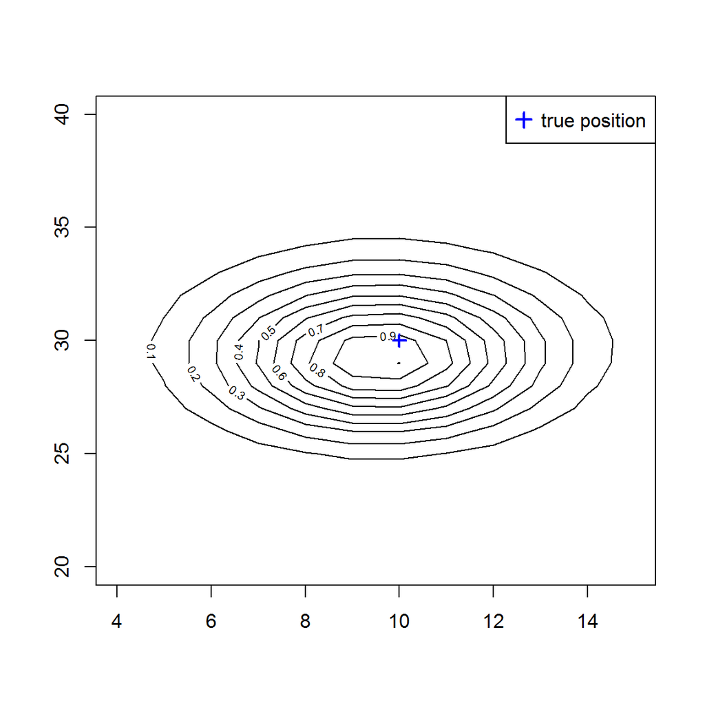

```r
contour(alphas, betas, grid_values, xlim=c(4,15), ylim=c(20,40))
points(alpha, beta, pch=3, col="blue", lwd=2) # true value
legend("topright",c("true position"), col="blue", pch=3, pt.cex=1.2, pt.lwd=2)
```

## Using Stan

```r
library(rstan)
```

The next Stan program models our problem (adapted from [here](http://stats.stackexchange.com/questions/254907)):

```r
model <- '
  data {
    int<lower=0> N;
    real x_[N];
  }

  parameters {
    real alpha;
    real<lower=0> beta;
  }

  model {
    alpha ~ uniform(0, 20);
    beta  ~ uniform(0, 50);

    for (k in 1:N) {
      x_[k] ~ cauchy(alpha, beta);
    }
  }
'
```

Let’s compile and run the model in Stan:

```r
n <- 100  # get a subset of the data
stan_input <- list(x_=x_k[1:n], N=n)

fit  <- stan(model_code=model, data=stan_input, iter=1000, verbose=FALSE)
fit2 <- stan(fit=fit, data=stan_input, iter=5000, warmup=2000, verbose=FALSE)
```

```r
print(fit2, pars=c("alpha", "beta"))
```

```
## Inference for Stan model: 36eef3c3637fb3a9564529926f8463fe.
## 4 chains, each with iter=5000; warmup=2000; thin=1;
## post-warmup draws per chain=3000, total post-warmup draws=12000.
##
##        mean se_mean   sd  2.5%   25%   50%   75% 97.5% n_eff Rhat
## alpha  8.96    0.05 3.91  1.61  6.13  8.95 11.68 16.80  7079    1
## beta  30.29    0.05 4.18 22.84 27.45 29.98 32.88 39.18  8470    1
##
## Samples were drawn using NUTS(diag_e) at Wed Jan 11 17:25:35 2017.
## For each parameter, n_eff is a crude measure of effective sample size,
## and Rhat is the potential scale reduction factor on split chains (at
## convergence, Rhat=1).
```

These are the empirical posteriors (the vertical red line is the true parameter value):

```r
la <- extract(fit2)
alpha_hats <- as.numeric(la$alpha)
beta_hats  <- as.numeric(la$beta)
```

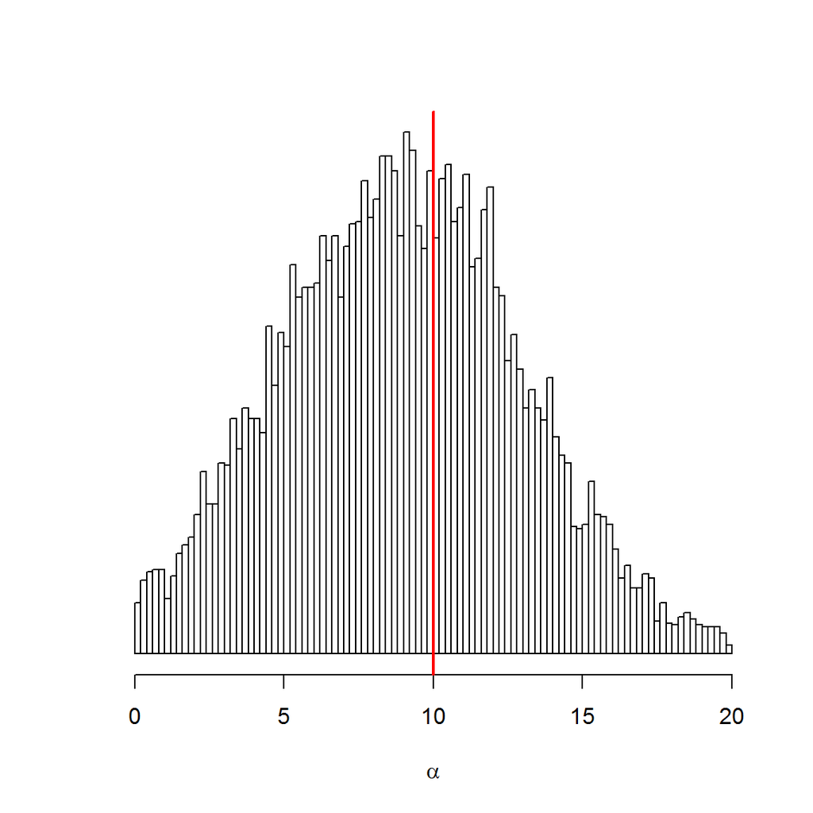

```r
hist(x=alpha_hats, breaks=100, xlab=bquote(alpha), ylab="",main="", yaxt='n')
abline(v=alpha, col="red", lwd=2)
```

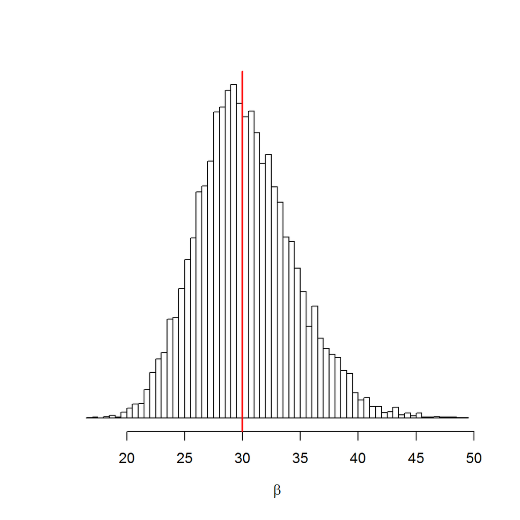

```r
hist(x=beta_hats, breaks=100, xlab=bquote(beta), ylab="",main="", yaxt='n')
abline(v=beta, col="red", lwd=2)
```